[figure not shown]

# Predicting MLB Teams' Regular Season Win Totals

#### CMSC320 Final Tutorial by Jason Schneider

## An Introduction

Predicting the outcomes of sporting events has been a hobby of sports fan and analysts for nearly as long as sport itself. Predicting sports outcomes is a crucial element of popular sports television like ESPN, sports gambling, fantasy sports, and coaching purposes. Out of all sports today, baseball, namely MLB (Major League Baseball), is currently the statistically-driven sport in America. This is thanks to the statistical revolution started by Bill James and was popularized by the Oakland Athletics' General Manager: Billy Beane. We explored Billy Beane and his application of data science and sabermetrical analysis in Project 2 earlier this semester, but the applications of sabermetrical analysis of baseball go beyond confirming a bias between poor and rich teams. We can use it to create a predictive model for various questions as well. The question we want to answer here is: **How can we accurately predict the number of regular season wins every MLB team will have next season?**  
Luckily, with the advancements in computational technologies, this and many more questions can be answered to various degrees of accuracy. While there are many, many methods and models out there that all argue they are the "most accurate," claim to "involve the latest trends in statistics," and "the most up-to-date techniques," there is no mathematical model that can 100% accurately predict every result. There's an old saying that *anything can happen in baseball*. What we hope to accomplish here is find a way to get as close to 100% accuracy as possible. In this tutorial, we will divise our own methods, statistics, and trends to base our model off of, different from those that already exist so we can use our own research to try to create the most accurate model possible, but also more simple so that it is easier for readers of this tutorial to follow along.

## Table of Contents

- **1 -> Getting Started**
  - 1.1 -> *Required Libraries*
  - 1.2 -> *Data Sources Used & Data Required*
  - 1.3 -> *Scraping, Loading, and Formatting Data*
  - 1.4 -> *End Goal Product*

## 1 Getting Started

### 1.1 Required Libraries

The required import libraries and matplotlib settings for this project are shown below with a brief description of their purpose (text in parenthesis represents alias used for import):

- **Math (math):** General math-based functionality not included in vanilla Python 3
- **Regular Expressions (re):** Regular Expression and replacement operations
- **Requests (rq):** GET Requests to data source sites
- **Pandas (pd):** Scraping, Manipulating, displaying, and formatting data
- **Numpy (np):** Sabermetrical analysis and aiding in matrix use
- **Matplotlib's Pyplot (pypt):** Basic graphing, plotting, and data analysis
- **Seaborn (sea):** More robust graphing, plotting, and modelling tools
- **scikit-learn's linear_model (lmod):** Aids in creating linear models involved in tutorial
- **BeautifulSoup4 (bsoup):** Scraping and importing data for use with Pandas
- **Scipy's Pearson Correlation (pr):** Validating relationships between certain stats/attributes and wins
- **Statsmodels's api (sm):** Performing Multiple Linear Regression in our "research"
- *%matplotlib inline:* Ensure that any Matplotlib plots are printed inline for notebook

```python
# Imports for all required libraries:

import math
import re
import requests as rq
import pandas as pd
import numpy as np
import matplotlib.pyplot as pypt
import seaborn as sea
from sklearn import linear_model as lmod
from bs4 import BeautifulSoup as bsoup
from scipy.stats import pearsonr as pr
from statsmodels import api as sm
%matplotlib inline
```

### 1.2 Data Source Used & Data Required

#### Data Source Used

The data source that we will be using is: *[Baseball Reference](https://www.baseball-reference.com/)*.  
*Baseball Reference* is a fantastic website and robust, expansive statistics data source for a wide range of baseball fans: from those who just picked their favorite team to those who want the edge in all 10 of their fantasy baseball leagues. In addition, it is very friendly to data scraping and has a clear, usable HTML DOM structure. In a sense, it can be considered the *Baseball Wikipedia*.  
Baseball Reference was launched in 2000 by Sean Forman, a Mathematics Professor at St. Joseph's University and baseball researcher.

#### Data Required

The data involved in predicting season win totals varies between every implementation of this idea. Why? **Briefly, every implementation places different emphasis of contrubtion for different correlations.** Our basic model will look much different than by companies who spend millions of dollars into researching but that doesn't mean we can't make an effective predictive model without doing so.  
While the actual specific data within these categories will be explored and explained later, the types of data we will be interested in retrieving are:

- **Constant Data:**
  - Team Names
  - Divisions
  - Leagues
- *n* Previous Seasons:
  - Win-Loss Record and Ratio
  - Regular Season Game Logs, containing things like (but not limited too)
    - Box Score
    - Game Time and Length
    - Weather
    - Player Performances
    - *etc...*
  - Team Performance Statistics
  - Player Performance Statistics

#### Things to Keep In Mind

We might not end up using all of this information if we find in our investigations that they are not needed, but this is a good general starting list for really any sport: Baseball, Football, Basketball, Hockey, Soccer, you name it.

For this tutorial, we will be using data from the last **n = 15** seasons by default, though more or less data may make the resulting model more or less accurate.

For the purposes of this tutorial, the divisions and leagues will be based offof the team names, divisions, and leagues as of the end of the 2019 MLB season. That means that the change of Tampa Bay's name to the Rays and the Astros' move to the American League in 2013 are treated as if they always existed that way.

Predictions and Past Data assumes that **162 Games** will be or were played, though this can change in rare cases like players union holdouts and tie-breaker games, which we will ignore as these are rather up to chance and are not up to our model to predict.

### 1.3 Scraping, Loading, and Formatting the Data

Now it's time to get all of the juicy, raw data we want from Baseball Reference into usable, cleanly formatted pandas dataframes. In order to do this, we need to make use of `requests`, `bs4` (BeautifulSoup4), and `pandas`. We need to:

1. Use **requests** to: Send **GET** requests to Baseball Reference for multiple Baseball Reference pages [MLB Team Win Totals](https://www.baseball-reference.com/leagues/MLB/) and MLB Season by Season Data for 2005 to 2019 seasons [(2019 version as example)](https://www.baseball-reference.com/leagues/MLB/2019.shtml)
2. Use **bs4** to: Find and store table elements
3. Use **pandas** to: Read html table elements into pandas dataframes, then to reformat and display data

We'll run through these steps with the constant data first as this is more straightforward and the we'll repeat these steps for past seasons data as it involves more steps.

```python
# Dealing with the "Constant Data" from the MLB Team Win Totals page #

# GET Request for MLB Team Win Totals Page
req_teamwintotals = rq.get("https://www.baseball-reference.com/leagues/MLB/")

# Parses request as HTML and finds and stores the desired table element
root_teamwintotals = bsoup(req_teamwintotals.content, "html")
table_teamwintotals = root_teamwintotals.find("table")

# Read the html element then create dataframe.  We will use all pre-existing column names (as they are in a great
# format already) unless otherwise shown in code.
pdtable_twt = pd.read_html(str(table_teamwintotals))
df_twt = pdtable_twt[0]

# Our new dataframe looks like:
df_twt
```

|  | Year | G | ARI | ATL | BLA | BAL | BOS | CHC | CHW | CIN | ... | PHI | PIT | SDP | SFG | SEA | STL | TBR | TEX | TOR | WSN |
| --- | --- | --- | --- | --- | --- | --- | --- | --- | --- | --- | --- | --- | --- | --- | --- | --- | --- | --- | --- | --- | --- |
| 0 | 2019 | 162 | 85 | 97 | NaN | 54 | 84 | 84 | 72 | 75 | ... | 81 | 69 | 70 | 77 | 68 | 91 | 96 | 78 | 67 | 93 |
| 1 | 2018 | 163 | 82 | 90 | NaN | 47 | 108 | 95 | 62 | 67 | ... | 80 | 82 | 66 | 73 | 89 | 88 | 90 | 67 | 73 | 82 |
| 2 | 2017 | 162 | 93 | 72 | NaN | 75 | 93 | 92 | 67 | 68 | ... | 66 | 75 | 71 | 64 | 78 | 83 | 80 | 78 | 76 | 97 |
| 3 | 2016 | 162 | 69 | 68 | NaN | 89 | 93 | 103 | 78 | 68 | ... | 71 | 78 | 68 | 87 | 86 | 86 | 68 | 95 | 89 | 95 |
| 4 | 2015 | 162 | 79 | 67 | NaN | 81 | 78 | 97 | 76 | 64 | ... | 63 | 98 | 74 | 84 | 76 | 100 | 80 | 88 | 93 | 83 |
| 5 | 2014 | 162 | 64 | 79 | NaN | 96 | 71 | 73 | 73 | 76 | ... | 73 | 88 | 77 | 88 | 87 | 90 | 77 | 67 | 83 | 96 |
| 6 | 2013 | 163 | 81 | 96 | NaN | 85 | 97 | 66 | 63 | 90 | ... | 73 | 94 | 76 | 76 | 71 | 97 | 92 | 91 | 74 | 86 |
| 7 | 2012 | 162 | 81 | 94 | NaN | 93 | 69 | 61 | 85 | 97 | ... | 81 | 79 | 76 | 94 | 75 | 88 | 90 | 93 | 73 | 98 |
| 8 | 2011 | 162 | 94 | 89 | NaN | 69 | 90 | 71 | 79 | 79 | ... | 102 | 72 | 71 | 86 | 67 | 90 | 91 | 96 | 81 | 80 |
| 9 | 2010 | 162 | 65 | 91 | NaN | 66 | 89 | 75 | 88 | 91 | ... | 97 | 57 | 90 | 92 | 61 | 86 | 96 | 90 | 85 | 69 |
| 10 | 2009 | 163 | 70 | 86 | NaN | 64 | 95 | 83 | 79 | 78 | ... | 93 | 62 | 75 | 88 | 85 | 91 | 84 | 87 | 75 | 59 |
| 11 | 2008 | 163 | 82 | 72 | NaN | 68 | 95 | 97 | 89 | 74 | ... | 92 | 67 | 63 | 72 | 61 | 86 | 97 | 79 | 86 | 59 |
| 12 | 2007 | 163 | 90 | 84 | NaN | 69 | 96 | 85 | 72 | 72 | ... | 89 | 68 | 89 | 71 | 88 | 78 | 66 | 75 | 83 | 73 |
| 13 | 2006 | 162 | 76 | 79 | NaN | 70 | 86 | 66 | 90 | 80 | ... | 85 | 67 | 88 | 76 | 78 | 83 | 61 | 80 | 87 | 71 |
| 14 | 2005 | 162 | 77 | 90 | NaN | 74 | 95 | 79 | 99 | 73 | ... | 88 | 67 | 82 | 75 | 69 | 100 | 67 | 79 | 80 | 81 |
| 15 | 2004 | 162 | 51 | 96 | NaN | 78 | 98 | 89 | 83 | 76 | ... | 86 | 72 | 87 | 91 | 63 | 105 | 70 | 89 | 67 | 67 |
| 16 | 2003 | 162 | 84 | 101 | NaN | 71 | 95 | 88 | 86 | 69 | ... | 86 | 75 | 64 | 100 | 93 | 85 | 63 | 71 | 86 | 83 |
| 17 | 2002 | 162 | 98 | 101 | NaN | 67 | 93 | 67 | 81 | 78 | ... | 80 | 72 | 66 | 95 | 93 | 97 | 55 | 72 | 78 | 83 |
| 18 | 2001 | 162 | 92 | 88 | NaN | 63 | 82 | 88 | 83 | 66 | ... | 86 | 62 | 79 | 90 | 116 | 93 | 62 | 73 | 80 | 68 |
| 19 | 2000 | 162 | 85 | 95 | NaN | 74 | 85 | 65 | 95 | 85 | ... | 65 | 69 | 76 | 97 | 91 | 95 | 69 | 71 | 83 | 67 |
| 20 | 1999 | 163 | 100 | 103 | NaN | 78 | 94 | 67 | 75 | 96 | ... | 77 | 78 | 74 | 86 | 79 | 75 | 69 | 95 | 84 | 68 |
| 21 | 1998 | 163 | 65 | 106 | NaN | 79 | 92 | 90 | 80 | 77 | ... | 75 | 69 | 98 | 89 | 76 | 83 | 63 | 88 | 88 | 65 |
| 22 | 1997 | 162 | NaN | 101 | NaN | 98 | 78 | 68 | 80 | 76 | ... | 68 | 79 | 76 | 90 | 90 | 73 | NaN | 77 | 76 | 78 |
| 23 | 1996 | 162 | NaN | 96 | NaN | 88 | 85 | 76 | 85 | 81 | ... | 67 | 73 | 91 | 68 | 85 | 88 | NaN | 90 | 74 | 88 |
| 24 | 1995 | 145 | NaN | 90 | NaN | 71 | 86 | 73 | 68 | 85 | ... | 69 | 58 | 70 | 67 | 79 | 62 | NaN | 74 | 56 | 66 |
| 25 | Year | G | ARI | ATL | BLA | BAL | BOS | CHC | CHW | CIN | ... | PHI | PIT | SDP | SFG | SEA | STL | TBR | TEX | TOR | WSN |
| 26 | 1994 | 117 | NaN | 68 | NaN | 63 | 54 | 49 | 67 | 66 | ... | 54 | 53 | 47 | 55 | 49 | 53 | NaN | 52 | 55 | 74 |
| 27 | 1993 | 162 | NaN | 104 | NaN | 85 | 80 | 84 | 94 | 73 | ... | 97 | 75 | 61 | 103 | 82 | 87 | NaN | 86 | 95 | 94 |
| 28 | 1992 | 162 | NaN | 98 | NaN | 89 | 73 | 78 | 86 | 90 | ... | 70 | 96 | 82 | 72 | 64 | 83 | NaN | 77 | 96 | 87 |
| 29 | 1991 | 162 | NaN | 94 | NaN | 67 | 84 | 77 | 87 | 74 | ... | 78 | 98 | 84 | 75 | 83 | 84 | NaN | 85 | 91 | 71 |
| ... | ... | ... | ... | ... | ... | ... | ... | ... | ... | ... | ... | ... | ... | ... | ... | ... | ... | ... | ... | ... | ... |
| 93 | 1929 | 154 | NaN | 56 | NaN | 79 | 58 | 98 | 59 | 66 | ... | 71 | 88 | NaN | 84 | NaN | 78 | NaN | NaN | NaN | NaN |
| 94 | 1928 | 154 | NaN | 50 | NaN | 82 | 57 | 91 | 72 | 78 | ... | 43 | 85 | NaN | 93 | NaN | 95 | NaN | NaN | NaN | NaN |
| 95 | 1927 | 154 | NaN | 60 | NaN | 59 | 51 | 85 | 70 | 75 | ... | 51 | 94 | NaN | 92 | NaN | 92 | NaN | NaN | NaN | NaN |
| 96 | 1926 | 154 | NaN | 66 | NaN | 62 | 46 | 82 | 81 | 87 | ... | 58 | 84 | NaN | 74 | NaN | 89 | NaN | NaN | NaN | NaN |
| 97 | 1925 | 154 | NaN | 70 | NaN | 82 | 47 | 68 | 79 | 80 | ... | 68 | 95 | NaN | 86 | NaN | 77 | NaN | NaN | NaN | NaN |
| 98 | 1924 | 154 | NaN | 53 | NaN | 74 | 67 | 81 | 66 | 83 | ... | 55 | 90 | NaN | 93 | NaN | 65 | NaN | NaN | NaN | NaN |
| 99 | 1923 | 154 | NaN | 54 | NaN | 74 | 61 | 83 | 69 | 91 | ... | 50 | 87 | NaN | 95 | NaN | 79 | NaN | NaN | NaN | NaN |
| 100 | 1922 | 154 | NaN | 53 | NaN | 93 | 61 | 80 | 77 | 86 | ... | 57 | 85 | NaN | 93 | NaN | 85 | NaN | NaN | NaN | NaN |
| 101 | 1921 | 154 | NaN | 79 | NaN | 81 | 75 | 64 | 62 | 70 | ... | 51 | 90 | NaN | 94 | NaN | 87 | NaN | NaN | NaN | NaN |
| 102 | 1920 | 154 | NaN | 62 | NaN | 76 | 72 | 75 | 96 | 82 | ... | 62 | 79 | NaN | 86 | NaN | 75 | NaN | NaN | NaN | NaN |
| 103 | Year | G | ARI | ATL | BLA | BAL | BOS | CHC | CHW | CIN | ... | PHI | PIT | SDP | SFG | SEA | STL | TBR | TEX | TOR | WSN |
| 104 | 1919 | 140 | NaN | 57 | NaN | 67 | 66 | 75 | 88 | 96 | ... | 47 | 71 | NaN | 87 | NaN | 54 | NaN | NaN | NaN | NaN |
| 105 | 1918 | 129 | NaN | 53 | NaN | 58 | 75 | 84 | 57 | 68 | ... | 55 | 65 | NaN | 71 | NaN | 51 | NaN | NaN | NaN | NaN |
| 106 | 1917 | 154 | NaN | 72 | NaN | 57 | 90 | 74 | 100 | 78 | ... | 87 | 51 | NaN | 98 | NaN | 82 | NaN | NaN | NaN | NaN |
| 107 | 1916 | 154 | NaN | 89 | NaN | 79 | 91 | 67 | 89 | 60 | ... | 91 | 65 | NaN | 86 | NaN | 60 | NaN | NaN | NaN | NaN |
| 108 | 1915 | 154 | NaN | 83 | NaN | 63 | 101 | 73 | 93 | 71 | ... | 90 | 73 | NaN | 69 | NaN | 72 | NaN | NaN | NaN | NaN |
| 109 | 1914 | 154 | NaN | 94 | NaN | 71 | 91 | 78 | 70 | 60 | ... | 74 | 69 | NaN | 84 | NaN | 81 | NaN | NaN | NaN | NaN |
| 110 | 1913 | 154 | NaN | 69 | NaN | 57 | 79 | 88 | 78 | 64 | ... | 88 | 78 | NaN | 101 | NaN | 51 | NaN | NaN | NaN | NaN |
| 111 | 1912 | 154 | NaN | 52 | NaN | 53 | 105 | 91 | 78 | 75 | ... | 73 | 93 | NaN | 103 | NaN | 63 | NaN | NaN | NaN | NaN |
| 112 | 1911 | 154 | NaN | 44 | NaN | 45 | 78 | 92 | 77 | 70 | ... | 79 | 85 | NaN | 99 | NaN | 75 | NaN | NaN | NaN | NaN |
| 113 | 1910 | 154 | NaN | 53 | NaN | 47 | 81 | 104 | 68 | 75 | ... | 78 | 86 | NaN | 91 | NaN | 63 | NaN | NaN | NaN | NaN |
| 114 | 1909 | 153 | NaN | 45 | NaN | 61 | 88 | 104 | 78 | 77 | ... | 74 | 110 | NaN | 92 | NaN | 54 | NaN | NaN | NaN | NaN |
| 115 | 1908 | 154 | NaN | 63 | NaN | 83 | 75 | 99 | 88 | 73 | ... | 83 | 98 | NaN | 98 | NaN | 49 | NaN | NaN | NaN | NaN |
| 116 | 1907 | 154 | NaN | 58 | NaN | 69 | 59 | 107 | 87 | 66 | ... | 83 | 91 | NaN | 82 | NaN | 52 | NaN | NaN | NaN | NaN |
| 117 | 1906 | 154 | NaN | 49 | NaN | 76 | 49 | 116 | 93 | 64 | ... | 71 | 93 | NaN | 96 | NaN | 52 | NaN | NaN | NaN | NaN |
| 118 | 1905 | 154 | NaN | 51 | NaN | 54 | 78 | 92 | 92 | 79 | ... | 83 | 96 | NaN | 105 | NaN | 58 | NaN | NaN | NaN | NaN |
| 119 | 1904 | 154 | NaN | 55 | NaN | 65 | 95 | 93 | 89 | 88 | ... | 52 | 87 | NaN | 106 | NaN | 75 | NaN | NaN | NaN | NaN |
| 120 | 1903 | 140 | NaN | 58 | NaN | 65 | 91 | 82 | 60 | 74 | ... | 49 | 91 | NaN | 84 | NaN | 43 | NaN | NaN | NaN | NaN |
| 121 | 1902 | 140 | NaN | 73 | 50 | 78 | 77 | 68 | 74 | 70 | ... | 56 | 103 | NaN | 48 | NaN | 56 | NaN | NaN | NaN | NaN |
| 122 | 1901 | 140 | NaN | 69 | 68 | 48 | 79 | 53 | 83 | 52 | ... | 83 | 90 | NaN | 52 | NaN | 76 | NaN | NaN | NaN | NaN |

123 rows × 33 columns

```python
# Now that we have gotten the data, we need to clean it up so we can use it.  We need to remove the unnecessary BLA
# and G (Games Played) column (BLA is a team that only existed around the 1900s and we said G will "always" be 162),
# replace missing data with np.nan, and limit this data to just the past 15 seasons (2005 to 2019 as of 12/16/19).
# Before we do any of that, we need to remove the repitition of the headers every 20 years.

df_twt = df_twt[df_twt.Year != "Year"]
df_twt = df_twt.drop(columns=["G", "BLA"])
df_twt = df_twt.replace("NaN", np.nan)
df_twt = df_twt.replace("", np.nan)
df_twt["Year"] = pd.to_numeric(df_twt["Year"])
df_twt = df_twt[df_twt["Year"] >= 2005]
df_twt = df_twt[df_twt["Year"] <= 2019]
df_twt = df_twt.sort_values("Year")
df_twt = df_twt.reset_index(drop = True)

# Here is our formatted, cleaned up dataframe for the MLB Team Team Win Totals data
df_twt
```

|  | Year | ARI | ATL | BAL | BOS | CHC | CHW | CIN | CLE | COL | ... | PHI | PIT | SDP | SFG | SEA | STL | TBR | TEX | TOR | WSN |
| --- | --- | --- | --- | --- | --- | --- | --- | --- | --- | --- | --- | --- | --- | --- | --- | --- | --- | --- | --- | --- | --- |
| 0 | 2005 | 77 | 90 | 74 | 95 | 79 | 99 | 73 | 93 | 67 | ... | 88 | 67 | 82 | 75 | 69 | 100 | 67 | 79 | 80 | 81 |
| 1 | 2006 | 76 | 79 | 70 | 86 | 66 | 90 | 80 | 78 | 76 | ... | 85 | 67 | 88 | 76 | 78 | 83 | 61 | 80 | 87 | 71 |
| 2 | 2007 | 90 | 84 | 69 | 96 | 85 | 72 | 72 | 96 | 90 | ... | 89 | 68 | 89 | 71 | 88 | 78 | 66 | 75 | 83 | 73 |
| 3 | 2008 | 82 | 72 | 68 | 95 | 97 | 89 | 74 | 81 | 74 | ... | 92 | 67 | 63 | 72 | 61 | 86 | 97 | 79 | 86 | 59 |
| 4 | 2009 | 70 | 86 | 64 | 95 | 83 | 79 | 78 | 65 | 92 | ... | 93 | 62 | 75 | 88 | 85 | 91 | 84 | 87 | 75 | 59 |
| 5 | 2010 | 65 | 91 | 66 | 89 | 75 | 88 | 91 | 69 | 83 | ... | 97 | 57 | 90 | 92 | 61 | 86 | 96 | 90 | 85 | 69 |
| 6 | 2011 | 94 | 89 | 69 | 90 | 71 | 79 | 79 | 80 | 73 | ... | 102 | 72 | 71 | 86 | 67 | 90 | 91 | 96 | 81 | 80 |
| 7 | 2012 | 81 | 94 | 93 | 69 | 61 | 85 | 97 | 68 | 64 | ... | 81 | 79 | 76 | 94 | 75 | 88 | 90 | 93 | 73 | 98 |
| 8 | 2013 | 81 | 96 | 85 | 97 | 66 | 63 | 90 | 92 | 74 | ... | 73 | 94 | 76 | 76 | 71 | 97 | 92 | 91 | 74 | 86 |
| 9 | 2014 | 64 | 79 | 96 | 71 | 73 | 73 | 76 | 85 | 66 | ... | 73 | 88 | 77 | 88 | 87 | 90 | 77 | 67 | 83 | 96 |
| 10 | 2015 | 79 | 67 | 81 | 78 | 97 | 76 | 64 | 81 | 68 | ... | 63 | 98 | 74 | 84 | 76 | 100 | 80 | 88 | 93 | 83 |
| 11 | 2016 | 69 | 68 | 89 | 93 | 103 | 78 | 68 | 94 | 75 | ... | 71 | 78 | 68 | 87 | 86 | 86 | 68 | 95 | 89 | 95 |
| 12 | 2017 | 93 | 72 | 75 | 93 | 92 | 67 | 68 | 102 | 87 | ... | 66 | 75 | 71 | 64 | 78 | 83 | 80 | 78 | 76 | 97 |
| 13 | 2018 | 82 | 90 | 47 | 108 | 95 | 62 | 67 | 91 | 91 | ... | 80 | 82 | 66 | 73 | 89 | 88 | 90 | 67 | 73 | 82 |
| 14 | 2019 | 85 | 97 | 54 | 84 | 84 | 72 | 75 | 93 | 71 | ... | 81 | 69 | 70 | 77 | 68 | 91 | 96 | 78 | 67 | 93 |

15 rows × 31 columns

```python
# Dealing with Previous Seasons' data, on the various MLB Season by Season data pages #

# Since we need to get data from multiple seasons and multiple tables from each season, we'll need to make use of
# loops and perform these steps on each table then stitch together and organize this data into a few more manageable
# "master" tables.

# We want to get and create dataframes for: Team Standard Batting, Team Standard Pitching, and the first two columns
# of MLB Wins Above Avg By Position (also known as WAR).  For purposes of this tutorial, we won't worry about fielding
# as WAR is a complex statistic (explained more later) that includes a player's fielding.  WAR will be explained more
# later, but it is a central statistic to our predictions and is something we will analyze thoroughly.

comments = re.compile("<!--|-->") # Need this to remove comments restricting us from scraping all tables
coldiv = []
df_master = pd.DataFrame()

for i in range(0, 33):
        coldiv.append("***")

for year in range(2005, 2020):
    # Send GET request for given year, then use BeautifulSoup to find root HMTL
    req_yearsbs = rq.get("https://www.baseball-reference.com/leagues/MLB/" + str(year) + ".shtml")
    root_yearsbs = bsoup(comments.sub("", str(req_yearsbs.content)), "html")
    alltables_year = root_yearsbs.findAll("table")

    # Create Batting Dataframe
    table_yearbatting = alltables_year[1]
    pdtable_yb = pd.read_html(str(table_yearbatting))
    df_yb = pdtable_yb[0]

    # Create Pitching Dataframe
    table_yearpitching = alltables_year[2]
    pdtable_yp = pd.read_html(str(table_yearpitching))
    df_yp = pdtable_yp[0]

    # Create WAR Dataframe
    table_yearwar = alltables_year[3]
    pdtable_yw = pd.read_html(str(table_yearwar))
    df_yw = pdtable_yw[0]

    # Consolidate all data into "season master table," which we then fill all empty cells and existing NaNs with
    # np.nan, remove all duplicate columns that repeat redundant info (renaming columns if necessary), then add
    # placeholder dividing columns so we can things easier for ourselves later.

    df_yearmaster = df_yb.join(df_yp, lsuffix = "_b", rsuffix = "_p").join(df_yw, lsuffix = "", rsuffix = "_w")
    df_yearmaster = df_yearmaster.loc[:,~df_yearmaster.columns.duplicated()]
    df_yearmaster = df_yearmaster.rename(columns = {"Tm_b" : "Tm"})
    df_yearmaster = df_yearmaster.drop(columns = ["Tm_p"])
    df_yearmaster.insert(30, "Col_Div1", coldiv)
    df_yearmaster.insert(67, "Col_Div2", coldiv)

    # Lastly we need to include the year next to each of these teams so we know what season this data is for
    include_year = []
    for k in range(0, 33):
        include_year.append(year)
    df_yearmaster.insert(0, "Year", include_year)

    # Now, if we've already created the dataframe for the first season, 2005, we need to start consolidating this
    # master SEASON dataframe into a master MASTER (aka dataframe showing all 15 seasons) dataframe by adding each
    # season's data to the bottom of the master df_master dataframe
    if year == 2005:
        df_master = df_yearmaster
    else:
        df_master = df_master.append(df_yearmaster)

# Need to make manual replacements to keep team names consistent, by changing Tampa Bay and Miami's modern team
# abbreviations
df_master = df_master.replace("TBD", "TBR")
df_master = df_master.replace("FLA", "MIA")
df_master = df_master.replace("NaN", np.nan)
df_master = df_master.replace("nan", np.nan)
df_master = df_master.replace("", np.nan)
df_master = df_master.reset_index(drop = True)

# This is our new master table of data for the 2005-2019 seasons:
df_master
```

|  | Year | Tm | #Bat | BatAge | R/G | G_b | PA | AB | R_b | H_b | ... | 1B | 2B_w | 3B_w | SS | LF | CF | RF | OF (All) | DH | PH |
| --- | --- | --- | --- | --- | --- | --- | --- | --- | --- | --- | --- | --- | --- | --- | --- | --- | --- | --- | --- | --- | --- |
| 0 | 2005 | ARI | 43 | 30.3 | 4.30 | 162 | 6327 | 5550 | 696 | 1419 | ... | STL5.8 | PHI5.6 | NYY6.7 | ATL4.6 | PIT2.6 | ATL4.8 | LAA3.0 | ATL6.6 | CLE2.7 | PHI0.1 |
| 1 | 2005 | ATL | 45 | 28.1 | 4.75 | 162 | 6186 | 5486 | 769 | 1453 | ... | CHC5.5 | BAL4.6 | HOU4.1 | BAL3.3 | NYM2.6 | CLE4.2 | LAD2.3 | PHI6.0 | BOS2.5 | TOR0.1 |
| 2 | 2005 | BAL | 46 | 31.5 | 4.50 | 162 | 6134 | 5551 | 729 | 1492 | ... | TEX4.2 | ARI3.0 | NYM2.8 | CLE3.2 | BOS2.0 | PHI2.6 | SDP2.3 | CLE5.4 | NYY0.1 | BOS0.0 |
| 3 | 2005 | BOS | 52 | 31.3 | 5.62 | 162 | 6403 | 5626 | 910 | 1579 | ... | COL2.9 | STL2.5 | OAK1.9 | OAK2.7 | FLA1.9 | KCR2.5 | MIL2.2 | BOS5.0 | ARI0.0 | CLE0.0 |
| 4 | 2005 | CHC | 46 | 29.8 | 4.34 | 162 | 6161 | 5584 | 703 | 1506 | ... | NYY1.5 | LAA2.4 | ATL1.7 | PHI2.6 | TBD1.9 | STL2.5 | SEA1.5 | NYM3.5 | MIL0.0 | LAA-0.2 |
| 5 | 2005 | CHW | 38 | 29.3 | 4.57 | 162 | 6146 | 5529 | 741 | 1450 | ... | ARI1.5 | CLE2.3 | BAL1.7 | PIT2.3 | PHI1.9 | BOS1.8 | WSN1.5 | STL2.6 | PHI0.0 | STL-0.3 |
| 6 | 2005 | CIN | 46 | 28.6 | 5.03 | 163 | 6321 | 5565 | 820 | 1453 | ... | WSN1.2 | OAK2.0 | CHC1.4 | CIN2.0 | CLE1.7 | CIN1.7 | PHI1.5 | SDP2.4 | PIT0.0 | TEX-0.3 |
| 7 | 2005 | CLE | 38 | 27.5 | 4.88 | 162 | 6255 | 5609 | 790 | 1522 | ... | SEA1.1 | ATL1.9 | ARI1.1 | TBD1.8 | COL0.9 | MIN1.6 | ATL1.5 | CIN2.3 | SDP0.0 | MIL-0.4 |
| 8 | 2005 | COL | 54 | 27.2 | 4.57 | 162 | 6238 | 5542 | 740 | 1477 | ... | PHI1.1 | DET1.9 | STL1.0 | NYY1.4 | TOR0.6 | CHW1.3 | BOS1.2 | PIT2.1 | SFG0.0 | SDP-0.4 |
| 9 | 2005 | DET | 45 | 28.5 | 4.46 | 162 | 6136 | 5602 | 723 | 1521 | ... | MIL0.7 | TOR1.8 | DET0.9 | MIL1.3 | CIN0.6 | DET1.2 | NYY0.6 | LAD1.7 | STL0.0 | DET-0.4 |
| 10 | 2005 | MIA | 47 | 29.7 | 4.43 | 162 | 6214 | 5502 | 717 | 1499 | ... | CHW0.7 | LAD1.8 | MIL0.8 | HOU0.9 | SFG0.5 | NYM0.9 | STL0.0 | TBD1.7 | HOU0.0 | TBD-0.5 |
| 11 | 2005 | HOU | 36 | 30.2 | 4.25 | 163 | 6139 | 5462 | 693 | 1400 | ... | FLA0.4 | FLA1.7 | CIN0.6 | TEX0.9 | ATL0.3 | TOR0.9 | CIN0.0 | SEA1.2 | FLA0.0 | BAL-0.5 |
| 12 | 2005 | KCR | 46 | 28.0 | 4.33 | 162 | 6086 | 5503 | 701 | 1445 | ... | NYM0.3 | CHW0.6 | BOS0.6 | STL0.9 | ARI0.2 | LAD0.9 | NYM0.0 | MIL1.1 | ATL0.0 | FLA-0.6 |
| 13 | 2005 | LAA | 40 | 29.8 | 4.70 | 162 | 6186 | 5624 | 761 | 1520 | ... | DET0.0 | PIT0.3 | SEA0.4 | MIN0.3 | STL0.1 | SDP0.7 | CHW-0.2 | TOR0.8 | CHC0.0 | ATL-0.6 |
| 14 | 2005 | LAD | 44 | 28.6 | 4.23 | 162 | 6134 | 5433 | 685 | 1374 | ... | HOU-0.1 | HOU-0.1 | LAA0.1 | CHW0.0 | NYY-0.1 | TBD0.7 | ARI-0.3 | DET0.2 | CIN0.0 | OAK-0.7 |
| 15 | 2005 | MIL | 39 | 28.4 | 4.48 | 162 | 6156 | 5448 | 726 | 1413 | ... | LAA-0.3 | CHC-0.1 | COL-0.1 | COL0.0 | SEA-0.2 | OAK0.7 | TEX-0.4 | CHW0.0 | COL0.0 | CIN-0.8 |
| 16 | 2005 | MIN | 37 | 27.6 | 4.25 | 162 | 6192 | 5564 | 688 | 1441 | ... | BOS-0.4 | BOS-0.2 | TOR-0.2 | CHC-0.1 | TEX-0.2 | TEX0.6 | HOU-0.4 | TEX0.0 | LAD-0.1 | CHW-0.9 |
| 17 | 2005 | NYM | 42 | 28.8 | 4.46 | 162 | 6146 | 5505 | 722 | 1421 | ... | OAK-0.6 | SFG-0.3 | SDP-0.3 | LAA-0.2 | DET-0.5 | PIT0.5 | CLE-0.5 | WSN-0.5 | NYM-0.1 | SEA-1.0 |
| 18 | 2005 | NYY | 51 | 32.2 | 5.47 | 162 | 6406 | 5624 | 886 | 1552 | ... | CIN-0.6 | MIL-0.3 | TBD-0.4 | TOR-0.4 | SDP-0.6 | BAL0.2 | DET-0.5 | OAK-0.6 | TOR-0.2 | ARI-1.0 |
| 19 | 2005 | OAK | 41 | 28.6 | 4.77 | 162 | 6275 | 5627 | 772 | 1476 | ... | TOR-0.7 | TEX-0.6 | PIT-0.4 | NYM-0.6 | OAK-0.6 | MIL0.1 | OAK-0.7 | LAA-0.6 | WSN-0.2 | NYM-1.1 |
| 20 | 2005 | PHI | 40 | 30.0 | 4.98 | 162 | 6345 | 5542 | 807 | 1494 | ... | TBD-0.9 | WSN-0.7 | CHW-0.6 | SFG-0.7 | HOU-1.0 | HOU-0.1 | TOR-0.7 | FLA-1.0 | DET-0.3 | CHC-1.2 |
| 21 | 2005 | PIT | 44 | 27.4 | 4.20 | 162 | 6221 | 5573 | 680 | 1445 | ... | CLE-1.0 | CIN-0.9 | CLE-0.7 | DET-0.8 | CHW-1.1 | SEA-0.1 | TBD-0.9 | HOU-1.5 | LAA-0.3 | MIN-1.2 |
| 22 | 2005 | SDP | 46 | 31.0 | 4.22 | 162 | 6271 | 5502 | 684 | 1416 | ... | SFG-1.0 | TBD-1.1 | WSN-1.0 | SDP-1.1 | MIL-1.2 | WSN-0.4 | PIT-1.0 | MIN-1.7 | SEA-0.3 | HOU-1.3 |
| 23 | 2005 | SEA | 48 | 28.7 | 4.31 | 162 | 6095 | 5507 | 699 | 1408 | ... | LAD-1.1 | SDP-1.2 | PHI-1.0 | BOS-1.4 | LAD-1.5 | SFG-1.4 | FLA-1.1 | KCR-2.2 | TBD-0.6 | PIT-1.4 |
| 24 | 2005 | SFG | 50 | 32.2 | 4.01 | 162 | 6077 | 5462 | 649 | 1427 | ... | MIN-1.4 | NYY-2.0 | LAD-1.0 | FLA-1.7 | WSN-1.6 | FLA-1.8 | COL-1.4 | SFG-2.5 | MIN-1.0 | WSN-1.6 |
| 25 | 2005 | STL | 40 | 30.8 | 4.97 | 162 | 6246 | 5538 | 805 | 1494 | ... | SDP-1.4 | NYM-2.4 | MIN-1.6 | ARI-1.9 | LAA-1.7 | LAA-1.9 | MIN-1.5 | ARI-3.0 | BAL-1.2 | NYY-1.6 |
| 26 | 2005 | TBR | 43 | 27.5 | 4.63 | 162 | 6120 | 5552 | 750 | 1519 | ... | BAL-2.0 | MIN-2.4 | FLA-1.8 | LAD-2.0 | MIN-1.8 | COL-2.5 | SFG-1.6 | COL-3.0 | TEX-1.3 | LAD-1.7 |
| 27 | 2005 | TEX | 50 | 27.9 | 5.34 | 162 | 6301 | 5716 | 865 | 1528 | ... | KCR-2.3 | COL-2.5 | TEX-2.2 | SEA-2.1 | BAL-2.1 | CHC-2.7 | CHC-2.0 | NYY-3.3 | CHW-1.7 | COL-1.8 |
| 28 | 2005 | TOR | 37 | 27.9 | 4.78 | 162 | 6233 | 5581 | 775 | 1480 | ... | ATL-2.6 | SEA-2.8 | SFG-2.5 | WSN-2.9 | CHC-2.5 | ARI-2.9 | KCR-2.0 | BAL-3.9 | KCR-1.7 | KCR-2.0 |
| 29 | 2005 | WSN | 55 | 29.3 | 3.94 | 162 | 6142 | 5426 | 639 | 1367 | ... | PIT-2.9 | KCR-3.6 | KCR-3.0 | KCR-3.2 | KCR-2.7 | NYY-3.8 | BAL-2.0 | CHC-7.2 | OAK-2.6 | SFG-2.2 |
| ... | ... | ... | ... | ... | ... | ... | ... | ... | ... | ... | ... | ... | ... | ... | ... | ... | ... | ... | ... | ... | ... |
| 465 | 2019 | BOS | 47 | 27.3 | 5.56 | 162 | 6475 | 5770 | 901 | 1554 | ... | ATL2.2 | ARI2.3 | COL3.5 | SDP3.5 | TBR1.7 | ARI2.5 | NYY3.8 | MIL5.6 | LAA0.8 | NYY0.4 |
| 466 | 2019 | CHC | 52 | 27.7 | 5.02 | 162 | 6195 | 5461 | 814 | 1378 | ... | CHC1.9 | HOU1.9 | ATL3.5 | MIN3.0 | LAD1.1 | HOU2.4 | PHI1.9 | LAA4.6 | KCR0.4 | TBR0.2 |
| 467 | 2019 | CHW | 47 | 27.6 | 4.40 | 161 | 6042 | 5529 | 708 | 1443 | ... | CLE1.2 | LAD1.6 | BOS2.6 | ARI2.8 | CHC0.5 | NYY2.2 | NYM1.5 | WSN4.0 | BOS0.3 | OAK-0.2 |
| 468 | 2019 | CIN | 47 | 27.8 | 4.33 | 162 | 6100 | 5450 | 701 | 1328 | ... | NYY0.8 | TBR1.3 | NYY2.4 | BOS2.6 | TEX0.3 | WSN1.6 | HOU1.5 | BOS3.5 | LAD0.1 | CLE-0.3 |
| 469 | 2019 | CLE | 54 | 27.7 | 4.75 | 162 | 6124 | 5425 | 769 | 1354 | ... | PIT0.7 | BAL1.2 | CHW2.3 | CHC2.4 | NYM0.2 | ATL1.4 | MIN1.0 | MIN3.3 | MIL0.1 | STL-0.3 |
| 470 | 2019 | COL | 50 | 28.2 | 5.15 | 162 | 6288 | 5660 | 835 | 1502 | ... | STL0.5 | TOR1.0 | LAD2.3 | LAD2.4 | OAK0.1 | LAD1.4 | TBR0.8 | OAK3.3 | TEX0.1 | TEX-0.4 |
| 471 | 2019 | DET | 53 | 27.6 | 3.61 | 161 | 6039 | 5549 | 582 | 1333 | ... | TBR0.5 | MIL0.9 | CIN2.1 | TBR2.1 | STL0.0 | PIT1.2 | OAK0.2 | TBR3.0 | ATL0.1 | ARI-0.4 |
| 472 | 2019 | HOU | 45 | 29.0 | 5.68 | 162 | 6394 | 5613 | 920 | 1538 | ... | ARI0.3 | LAA0.5 | CHC1.5 | STL1.8 | MIL0.0 | TEX0.9 | CLE0.2 | PHI1.5 | MIA0.0 | SEA-0.5 |
| 473 | 2019 | KCR | 51 | 27.6 | 4.27 | 162 | 6080 | 5496 | 691 | 1356 | ... | SEA0.3 | PIT0.5 | MIN1.3 | CHW1.8 | PHI-0.2 | STL0.8 | KCR0.2 | ATL0.9 | PIT0.0 | ATL-0.5 |
| 474 | 2019 | LAA | 57 | 28.8 | 4.75 | 162 | 6251 | 5542 | 769 | 1368 | ... | HOU0.0 | PHI0.4 | ARI1.1 | CLE1.6 | PIT-0.2 | MIL0.8 | LAA0.2 | TEX0.3 | CIN0.0 | MIL-0.6 |
| 475 | 2019 | LAD | 46 | 27.9 | 5.47 | 162 | 6282 | 5493 | 886 | 1414 | ... | MIN-0.3 | MIN0.3 | CLE1.0 | TOR1.4 | MIN-0.3 | TBR0.5 | CHC0.2 | NYM0.1 | CHC0.0 | LAA-0.7 |
| 476 | 2019 | MIA | 50 | 28.4 | 3.80 | 162 | 6045 | 5512 | 615 | 1326 | ... | CIN-0.5 | WSN0.2 | SFG0.8 | LAA0.5 | ARI-0.3 | BOS0.4 | CIN0.1 | ARI0.1 | WSN0.0 | WSN-0.7 |
| 477 | 2019 | MIL | 50 | 28.9 | 4.75 | 162 | 6309 | 5542 | 769 | 1366 | ... | PHI-0.8 | CHW-0.1 | NYM0.8 | MIA0.4 | ATL-0.3 | SDP-0.2 | COL0.0 | STL0.0 | NYM0.0 | SFG-0.7 |
| 478 | 2019 | MIN | 50 | 27.8 | 5.80 | 162 | 6392 | 5732 | 939 | 1547 | ... | MIL-0.8 | KCR-0.4 | SDP0.5 | NYY0.4 | SFG-0.5 | PHI-0.2 | BAL-0.1 | CHC-1.0 | SDP-0.1 | NYM-0.8 |
| 479 | 2019 | NYM | 53 | 27.9 | 4.88 | 162 | 6290 | 5624 | 791 | 1445 | ... | WSN-1.0 | NYM-0.8 | STL0.5 | PIT0.1 | TOR-0.6 | CHW-0.8 | ATL-0.2 | CLE-1.6 | STL-0.1 | KCR-0.9 |
| 480 | 2019 | NYY | 54 | 28.3 | 5.82 | 162 | 6245 | 5583 | 943 | 1493 | ... | CHW-1.1 | SDP-0.9 | SEA0.3 | KCR-0.1 | BOS-0.8 | SFG-0.9 | WSN-0.3 | PIT-1.7 | SFG-0.1 | TOR-0.9 |
| 481 | 2019 | OAK | 49 | 27.8 | 5.22 | 162 | 6269 | 5561 | 845 | 1384 | ... | BOS-1.3 | CLE-1.1 | MIA0.0 | TEX-0.4 | CLE-0.9 | CLE-0.9 | SDP-0.6 | KCR-2.3 | PHI-0.1 | CIN-1.0 |
| 482 | 2019 | PHI | 56 | 27.7 | 4.78 | 162 | 6261 | 5571 | 774 | 1369 | ... | MIA-1.4 | SEA-1.3 | BAL-0.3 | NYM-0.5 | KCR-1.0 | CIN-1.4 | STL-0.8 | SFG-2.3 | ARI-0.1 | CHC-1.0 |
| 483 | 2019 | PIT | 54 | 27.5 | 4.68 | 162 | 6228 | 5657 | 758 | 1497 | ... | SFG-1.4 | OAK-1.4 | LAA-0.3 | PHI-0.5 | LAA-1.3 | KCR-1.5 | SEA-0.8 | SDP-2.4 | COL-0.2 | BOS-1.2 |
| 484 | 2019 | SDP | 54 | 26.2 | 4.21 | 162 | 6019 | 5391 | 682 | 1281 | ... | BAL-1.7 | SFG-1.4 | TBR-0.5 | ATL-0.7 | SEA-1.4 | NYM-1.6 | TEX-0.9 | CIN-3.1 | SEA-0.2 | SDP-1.2 |
| 485 | 2019 | SEA | 67 | 27.8 | 4.68 | 162 | 6199 | 5500 | 758 | 1305 | ... | TEX-1.7 | COL-1.6 | TOR-0.6 | BAL-0.8 | SDP-1.6 | CHC-1.7 | SFG-0.9 | TOR-4.8 | NYY-0.3 | PHI-1.3 |
| 486 | 2019 | SFG | 64 | 29.9 | 4.19 | 162 | 6170 | 5579 | 678 | 1332 | ... | TOR-1.7 | CHC-1.9 | MIL-0.6 | CIN-0.8 | CHW-1.7 | DET-1.9 | MIA-1.0 | BAL-4.8 | TOR-0.8 | BAL-1.4 |
| 487 | 2019 | STL | 43 | 28.8 | 4.72 | 162 | 6167 | 5449 | 764 | 1336 | ... | DET-2.0 | TEX-2.1 | KCR-1.2 | SFG-1.0 | CIN-1.8 | TOR-1.9 | DET-2.1 | SEA-4.9 | BAL-1.1 | CHW-1.6 |
| 488 | 2019 | TBR | 57 | 27.2 | 4.75 | 162 | 6285 | 5628 | 769 | 1427 | ... | LAA-2.3 | BOS-2.1 | PHI-1.3 | SEA-1.0 | DET-2.2 | BAL-2.0 | ARI-2.1 | COL-5.8 | CLE-1.4 | DET-1.6 |
| 489 | 2019 | TEX | 53 | 28.8 | 5.00 | 162 | 6204 | 5540 | 810 | 1374 | ... | COL-2.3 | MIA-2.3 | TEX-1.9 | WSN-1.4 | BAL-2.7 | SEA-2.7 | TOR-2.3 | DET-6.2 | OAK-1.8 | PIT-2.1 |
| 490 | 2019 | TOR | 61 | 25.9 | 4.48 | 162 | 6091 | 5493 | 726 | 1299 | ... | SDP-2.4 | CIN-2.4 | DET-2.1 | DET-2.0 | COL-2.8 | COL-3.0 | PIT-2.7 | CHW-6.3 | CHW-2.5 | COL-2.8 |
| 491 | 2019 | WSN | 50 | 28.8 | 5.39 | 162 | 6267 | 5512 | 873 | 1460 | ... | KCR-4.0 | DET-2.9 | PIT-2.5 | MIL-2.2 | MIA-3.3 | MIA-3.6 | CHW-3.8 | MIA-7.9 | DET-2.6 | MIA-3.0 |
| 492 | 2019 | LgAvg | 47 | 27.9 | 4.83 | 162 | 6217 | 5555 | 782 | 1401 | ... | -0.3 | -0.1 | 0.9 | 1.0 | -0.4 | 0.1 | 0.2 | -0.1 | -0.1 | -0.8 |
| 493 | 2019 | Tm | #Bat | BatAge | R/G | G | PA | AB | R | H | ... | NaN | NaN | NaN | NaN | NaN | NaN | NaN | NaN | NaN | NaN |
| 494 | 2019 | NaN | 1410 | 27.9 | 4.83 | 4858 | 186517 | 166651 | 23467 | 42039 | ... | NaN | NaN | NaN | NaN | NaN | NaN | NaN | NaN | NaN | NaN |

495 rows × 84 columns

### 1.4 End Goal Product

Before we dive into our analysis, research, and model creation, it's important to lay out our end goals so we can stay focused throughout the process as well as the format of our eventual predicted win totals. Our End Product should contain:

- Win Totals For Each Team
- Projected Playoff Teams

## 2 What Statistics Contribute to More Wins?

### 2.1 Choosing a Starting Point

With so many new statistics and vast amounts of data in modern-day baseball, it can seem quite daunting to try and analyze every possible statistic and its relationship to number of wins and then somehow piece it together. The best models are constantly being reworked, tweaked, and updated in order to be as accurate as possible, but they don't simply go from raw data to a predictive model. They all start from the ground up, finding statistics that have strong correlations with wins first and then moving up from there.  
As an avid baseball fan who already has experience with some basic forms of sabermetrics (such as in fantasy baseball), I have a general idea of where I want to start looking for correlations, but if you are not as big of a baseball fan, then there are many resources on the internet that can provide you some good starting points. As stated before, we will try not to incorporate too many statistics into the end product for the purposes of this tutorial as that would take an extensive amount of time and likely lose the reader in the process.

### 2.2 Example of Relationship Analyzation: Batting Average!

One of the most well-known baseball statistics is batting average. Batting Average for an entire team is similar to how it is calculated for an individual player: **.AVG = Teams' Total # of Hits / Teams' Total # of At- Bats**.  
Baseball Reference provides these pieces of information for every team in every season. In addition, they already have the batting averages calculated in its own column, so we do not have to calculate it ourselves.

#### Analyzing for a Correlation

To analyze a potential correlation between batting average and regular season wins, we need to plot **wins vs. team batting average**. To do this, we need to draw from our season wins dataframe and our master stats dataframe in order to create a new 2 column dataframe of: a team from a given season's batting average and that same team in that given season's total regular season wins. Then, we plot all 15 seasons of this data and fit a linear regression model to it.

```python
# Creating the dataframe to plot
df_winsbavg = pd.DataFrame()

build_wincol = []

# Need to reference each row of the total wins table to append each column value in order to match up with batting avg
for row in df_twt.values:
    for col_ind in range(1, 31):
        build_wincol.append(float(row[col_ind]))

# Need to remove any rows that do not contain just a batting average in a copy of df_master
copy_dfm = df_master[df_master.BA.str[0] == "."]
copy_dfm = copy_dfm[copy_dfm["Tm"] != "LgAvg"]
copy_dfm = copy_dfm[copy_dfm["Tm"] != "Tm"]
copy_dfm = copy_dfm[copy_dfm["Tm"] != "BA"]
copy_dfm = copy_dfm[copy_dfm["Tm"] != np.nan]
copy_dfm = copy_dfm[pd.isnull(copy_dfm["Tm"]) == False]
copy_dfm["BA"] = copy_dfm["BA"].astype(float)
copy_dfm = copy_dfm.reset_index(drop = True)

# Now we can add build_wincol as the wins column with all indicies matching up for their respective batting avg data
df_winsbavg["Batting Avg"] = copy_dfm["BA"]
df_winsbavg["Wins"] = build_wincol

# Our dataframe is now ready to plot:
df_winsbavg
```

|  | Batting Avg | Wins |
| --- | --- | --- |
| 0 | 0.256 | 77.0 |
| 1 | 0.265 | 90.0 |
| 2 | 0.269 | 74.0 |
| 3 | 0.281 | 95.0 |
| 4 | 0.270 | 79.0 |
| 5 | 0.262 | 99.0 |
| 6 | 0.261 | 73.0 |
| 7 | 0.271 | 93.0 |
| 8 | 0.267 | 67.0 |
| 9 | 0.272 | 71.0 |
| 10 | 0.272 | 89.0 |
| 11 | 0.256 | 56.0 |
| 12 | 0.263 | 95.0 |
| 13 | 0.270 | 71.0 |
| 14 | 0.253 | 83.0 |
| 15 | 0.259 | 81.0 |
| 16 | 0.259 | 83.0 |
| 17 | 0.258 | 83.0 |
| 18 | 0.276 | 95.0 |
| 19 | 0.262 | 88.0 |
| 20 | 0.270 | 88.0 |
| 21 | 0.259 | 67.0 |
| 22 | 0.257 | 82.0 |
| 23 | 0.256 | 75.0 |
| 24 | 0.261 | 69.0 |
| 25 | 0.270 | 100.0 |
| 26 | 0.274 | 67.0 |
| 27 | 0.267 | 79.0 |
| 28 | 0.265 | 80.0 |
| 29 | 0.252 | 81.0 |
| ... | ... | ... |
| 420 | 0.252 | 85.0 |
| 421 | 0.258 | 97.0 |
| 422 | 0.246 | 54.0 |
| 423 | 0.269 | 84.0 |
| 424 | 0.252 | 84.0 |
| 425 | 0.261 | 72.0 |
| 426 | 0.244 | 75.0 |
| 427 | 0.250 | 93.0 |
| 428 | 0.265 | 71.0 |
| 429 | 0.240 | 47.0 |
| 430 | 0.274 | 107.0 |
| 431 | 0.247 | 59.0 |
| 432 | 0.247 | 72.0 |
| 433 | 0.257 | 106.0 |
| 434 | 0.241 | 57.0 |
| 435 | 0.246 | 89.0 |
| 436 | 0.270 | 101.0 |
| 437 | 0.257 | 86.0 |
| 438 | 0.267 | 103.0 |
| 439 | 0.249 | 97.0 |
| 440 | 0.246 | 81.0 |
| 441 | 0.265 | 69.0 |
| 442 | 0.238 | 70.0 |
| 443 | 0.237 | 77.0 |
| 444 | 0.239 | 68.0 |
| 445 | 0.245 | 91.0 |
| 446 | 0.254 | 96.0 |
| 447 | 0.248 | 78.0 |
| 448 | 0.236 | 67.0 |
| 449 | 0.265 | 93.0 |

450 rows × 2 columns

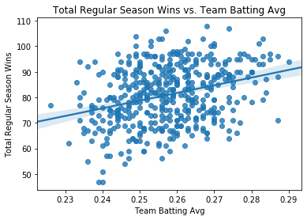

```python
# Rename copy_dfm to df_research for clarity
df_research = copy_dfm

# Now we want to plot this and fit a linear regression to the plot using Seaborn and sklearn's linear_model
lreg_winsbavg = lmod.LinearRegression()
lreg_X = [[x] for x in df_winsbavg["Batting Avg"].values]
lreg_Y = [[y] for y in df_winsbavg["Wins"].values]
lreg_fit = lreg_winsbavg.fit(lreg_X, lreg_Y)

regplot_winsbavg = sea.regplot(x = "Batting Avg", y = "Wins", data = df_winsbavg)
regplot_winsbavg.set(xlabel = "Team Batting Avg", ylabel = "Total Regular Season Wins",
                     title = "Total Regular Season Wins vs. Team Batting Avg")
regplot_winsbavg
```

```python
# From the graph above, it seems like a higher team batting average tends to contribute to more regular season wins.
# Using the linear regression we can create a linear equation in the form y = mx + b to predict how many regular
# season wins are expected based off of JUST a hypothetical whole season team batting average.
slope0 = lreg_winsbavg.coef_[0][0]
intercept0 = lreg_winsbavg.intercept_[0]

print("# of Regular Season Wins = " + str(slope0) + " * <Batting Avg> + " + str(intercept0))
print("Pearson Correlation: " + str(pr(df_winsbavg["Batting Avg"], df_winsbavg["Wins"])[0]))

# You've just completed your first basic statistic analyzation!
```

```
# of Regular Season Wins = 300.3002325179685 * <Batting Avg> + 3.6433407808888205
Pearson Correlation: 0.313334368854188
```

### 2.3 Relationship: Runs Scored and Wins

Next, I am going to explore the relationship between runs scored and wins. Do we expect there to be a correlation? Most likely, yes, as teams that score more runs during a whole season also score more runs during every game on average than teams that score less runs during a whole season.

```python
# Rename df_winsbavg to df_factors as this will now maintain important data on factors involved in our eventual
# complete predictive model
df_factors = df_winsbavg

# Add years, teams, and runs scored to our factors table
df_factors.insert(0, "Year", df_research["Year"].astype(int))
df_factors.insert(1, "Team", df_research["Tm"])
df_factors["Runs Scored"] = df_research["R_b"].astype(float)
df_factors
```

|  | Year | Team | Batting Avg | Wins | Runs Scored |
| --- | --- | --- | --- | --- | --- |
| 0 | 2005 | ARI | 0.256 | 77.0 | 696.0 |
| 1 | 2005 | ATL | 0.265 | 90.0 | 769.0 |
| 2 | 2005 | BAL | 0.269 | 74.0 | 729.0 |
| 3 | 2005 | BOS | 0.281 | 95.0 | 910.0 |
| 4 | 2005 | CHC | 0.270 | 79.0 | 703.0 |
| 5 | 2005 | CHW | 0.262 | 99.0 | 741.0 |
| 6 | 2005 | CIN | 0.261 | 73.0 | 820.0 |
| 7 | 2005 | CLE | 0.271 | 93.0 | 790.0 |
| 8 | 2005 | COL | 0.267 | 67.0 | 740.0 |
| 9 | 2005 | DET | 0.272 | 71.0 | 723.0 |
| 10 | 2005 | MIA | 0.272 | 89.0 | 717.0 |
| 11 | 2005 | HOU | 0.256 | 56.0 | 693.0 |
| 12 | 2005 | KCR | 0.263 | 95.0 | 701.0 |
| 13 | 2005 | LAA | 0.270 | 71.0 | 761.0 |
| 14 | 2005 | LAD | 0.253 | 83.0 | 685.0 |
| 15 | 2005 | MIL | 0.259 | 81.0 | 726.0 |
| 16 | 2005 | MIN | 0.259 | 83.0 | 688.0 |
| 17 | 2005 | NYM | 0.258 | 83.0 | 722.0 |
| 18 | 2005 | NYY | 0.276 | 95.0 | 886.0 |
| 19 | 2005 | OAK | 0.262 | 88.0 | 772.0 |
| 20 | 2005 | PHI | 0.270 | 88.0 | 807.0 |
| 21 | 2005 | PIT | 0.259 | 67.0 | 680.0 |
| 22 | 2005 | SDP | 0.257 | 82.0 | 684.0 |
| 23 | 2005 | SEA | 0.256 | 75.0 | 699.0 |
| 24 | 2005 | SFG | 0.261 | 69.0 | 649.0 |
| 25 | 2005 | STL | 0.270 | 100.0 | 805.0 |
| 26 | 2005 | TBR | 0.274 | 67.0 | 750.0 |
| 27 | 2005 | TEX | 0.267 | 79.0 | 865.0 |
| 28 | 2005 | TOR | 0.265 | 80.0 | 775.0 |
| 29 | 2005 | WSN | 0.252 | 81.0 | 639.0 |
| ... | ... | ... | ... | ... | ... |
| 420 | 2019 | ARI | 0.252 | 85.0 | 813.0 |
| 421 | 2019 | ATL | 0.258 | 97.0 | 855.0 |
| 422 | 2019 | BAL | 0.246 | 54.0 | 729.0 |
| 423 | 2019 | BOS | 0.269 | 84.0 | 901.0 |
| 424 | 2019 | CHC | 0.252 | 84.0 | 814.0 |
| 425 | 2019 | CHW | 0.261 | 72.0 | 708.0 |
| 426 | 2019 | CIN | 0.244 | 75.0 | 701.0 |
| 427 | 2019 | CLE | 0.250 | 93.0 | 769.0 |
| 428 | 2019 | COL | 0.265 | 71.0 | 835.0 |
| 429 | 2019 | DET | 0.240 | 47.0 | 582.0 |
| 430 | 2019 | HOU | 0.274 | 107.0 | 920.0 |
| 431 | 2019 | KCR | 0.247 | 59.0 | 691.0 |
| 432 | 2019 | LAA | 0.247 | 72.0 | 769.0 |
| 433 | 2019 | LAD | 0.257 | 106.0 | 886.0 |
| 434 | 2019 | MIA | 0.241 | 57.0 | 615.0 |
| 435 | 2019 | MIL | 0.246 | 89.0 | 769.0 |
| 436 | 2019 | MIN | 0.270 | 101.0 | 939.0 |
| 437 | 2019 | NYM | 0.257 | 86.0 | 791.0 |
| 438 | 2019 | NYY | 0.267 | 103.0 | 943.0 |
| 439 | 2019 | OAK | 0.249 | 97.0 | 845.0 |
| 440 | 2019 | PHI | 0.246 | 81.0 | 774.0 |
| 441 | 2019 | PIT | 0.265 | 69.0 | 758.0 |
| 442 | 2019 | SDP | 0.238 | 70.0 | 682.0 |
| 443 | 2019 | SEA | 0.237 | 77.0 | 758.0 |
| 444 | 2019 | SFG | 0.239 | 68.0 | 678.0 |
| 445 | 2019 | STL | 0.245 | 91.0 | 764.0 |
| 446 | 2019 | TBR | 0.254 | 96.0 | 769.0 |
| 447 | 2019 | TEX | 0.248 | 78.0 | 810.0 |
| 448 | 2019 | TOR | 0.236 | 67.0 | 726.0 |
| 449 | 2019 | WSN | 0.265 | 93.0 | 873.0 |

450 rows × 5 columns

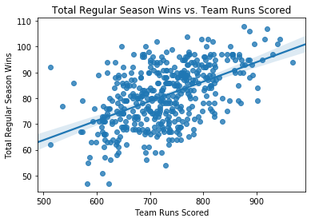

```python
# Plot, Fit Linear Regression, Create equation, and find Pearson Correlation similar to example
lreg_winsruns = lmod.LinearRegression()
winsruns_X = [[x] for x in df_factors["Runs Scored"].values]
winsruns_Y = [[y] for y in df_factors["Wins"].values]
winsruns_fit = lreg_winsruns.fit(winsruns_X, winsruns_Y)

regplot_winsruns = sea.regplot(x = "Runs Scored", y = "Wins", data = df_factors)
regplot_winsruns.set(xlabel = "Team Runs Scored", ylabel = "Total Regular Season Wins",
                     title = "Total Regular Season Wins vs. Team Runs Scored")
regplot_winsruns
```

```python
# The plot above shows that there is an even stronger correlation between Team Runs Scored in a Season and Total
# Regular Season Wins for that season.  The equation for the regression in y = mx + b format is:
slope1 = lreg_winsruns.coef_[0][0]
intercept1 = lreg_winsruns.intercept_[0]

print("# of Regular Season Wins = " + str(slope1) + " * <Runs Scored> + " + str(intercept1))
print("Pearson Correlation: " + str(pr(df_factors["Runs Scored"], df_factors["Wins"])[0]))
```

```
# of Regular Season Wins = 0.07568260885548721 * <Runs Scored> + 25.911759468227686
Pearson Correlation: 0.5189365795325355
```

#### Analysis Results

As expected, there is a clear correlation between team runs scored in a season and wins in a season. As stated before, a team that scores more runs is stastically more likely to win more games than a team that scores less runs as scoring runs is the only way to raise your teams' score in baseball, a sport where the objective is to score more runs than the other team.  
The equation for the linear regression is given in the output above and the Pearson Correlation is about 0.519, which is a solid, moderate positive correlation.

### 2.4 Relationship: WHIP and Wins

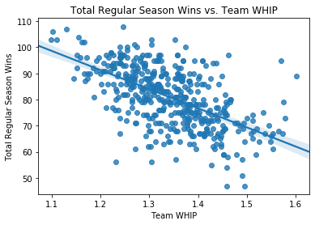

```python
# Add WHIP to factors table
df_factors["WHIP"] = df_research["WHIP"].astype(float)

# Plot, Fit Linear Regression, Create equation, and find Pearson Correlation similar to example
lreg_winswhip = lmod.LinearRegression()
winswhip_X = [[x] for x in df_factors["WHIP"].values]
winswhip_Y = [[y] for y in df_factors["Wins"].values]
winswhip_fit = lreg_winswhip.fit(winswhip_X, winswhip_Y)

regplot_winswhip = sea.regplot(x = "WHIP", y = "Wins", data = df_factors)
regplot_winswhip.set(xlabel = "Team WHIP", ylabel = "Total Regular Season Wins",
                     title = "Total Regular Season Wins vs. Team WHIP")
regplot_winswhip
```

```python
# The plot above shows that there is an evident negative correlation between Team WHIP and Total Regular Season Wins.
# The equation for the regression in y = mx + b format is:
slope2 = lreg_winswhip.coef_[0][0]
intercept2 = lreg_winswhip.intercept_[0]

print("# of Regular Season Wins = " + str(slope2) + " * <WHIP> + " + str(intercept2))
print("Pearson Correlation: " + str(pr(df_factors["WHIP"], df_factors["Wins"])[0]))
```

```
# of Regular Season Wins = -73.11937611201859 * <WHIP> + 179.04576207047504
Pearson Correlation: -0.5865951742238298
```

#### Analysis Results

As expected, there is a negative correlation between Team WHIP for a season and wins in a season. As stated before, a team that lets less runners on base per innings is going to end up giving up less runs as baserunners are required to score runs.  
The equation for the linear regression is given in the output above and the Pearson Correlation is about -0.587, which is a solid, moderate negative correlation.

### 2.5 Relationship: WAR and Wins

**WAR**, short for **Wins Above Replacement**, measures the "number of wins" a player's presence in the lineup for a whole 162-game season adds or subtracts from the team's overall record if the average league player were to play instead. A positive WAR means the player generally helps the team while a negative war means the player is costing their team wins (causing them to lose more). Calculating WAR involves several calculations and involves many different statistics, but we won't need to do that as Baseball Reference has done the calculations for us.  
The data for Team WAR is an average of the players' WARs for a given season, which means we can use Team WAR to take a quick glance at the teams with the most "win-helpful" players.

```python
# Re-format/Sort and then add WAR to factors table
build_warscol = pd.Series([])
switch = {
    "ARI" : 0,
    "ATL" : 1,
    "BAL" : 2,
    "BOS" : 3,
    "CHC" : 4,
    "CHW" : 5,
    "CIN" : 6,
    "CLE" : 7,
    "COL" : 8,
    "DET" : 9,
    "MIA" : 10,
    "HOU" : 11,
    "KCR" : 12,
    "LAA" : 13,
    "LAD" : 14,
    "MIL" : 15,
    "MIN" : 16,
    "NYM" : 17,
    "NYY" : 18,
    "OAK" : 19,
    "PHI" : 20,
    "PIT" : 21,
    "SDP" : 22,
    "SEA" : 23,
    "SFG" : 24,
    "STL" : 25,
    "TBR" : 26,
    "TEX" : 27,
    "TOR" : 28,
    "WSN" : 29,
    "FLA" : -1
}
for yr in range(2005, 2020):
    wars = df_research[df_research["Year"] == yr]
    wars = wars["Total"]
    wars = wars.replace("TBD", "TBR")
    wars = wars.replace("FLA", "MIA")
    build_local = []

    for war in wars.astype(str):
        team_code = war[0] + war[1] + war[2]
        local_index = switch.get(team_code)
        if local_index is not None:
            build_local.insert(local_index, team_code)
    if build_warscol is None:
        build_warscol = build_local
    else:
        build_warscol = build_warscol.append(pd.Series(build_local))
build_warscol = build_warscol.reset_index()
```

```python
# Then, you would average out all of you models against the average win amount for each team over the past 15 seasons
# and then find the average prediction of all the mini models.
```

[output not shown]

[output not shown]